# Project_3_Full_Code_Notebook_EasyVisa_Final_TBurrus_New

[figure not shown]

Artificial Intelligence and Machine Learning

Ensemble Techniques and Model Tuning

[figure not shown]

Visa Approval Facilitation

## Problem Statement

### Context

Business communities in the United States are facing high demand for human resources, but one of the constant challenges is identifying and attracting the right talent, which is perhaps the most important element in remaining competitive. Companies in the United States look for hard-working, talented, and qualified individuals both locally as well as abroad.

The Immigration and Nationality Act (INA) of the US permits foreign workers to come to the United States to work on either a temporary or permanent basis. The act also protects US workers against adverse impacts on their wages or working conditions by ensuring US employers' compliance with statutory requirements when they hire foreign workers to fill workforce shortages. The immigration programs are administered by the Office of Foreign Labor Certification (OFLC).

OFLC processes job certification applications for employers seeking to bring foreign workers into the United States and grants certifications in those cases where employers can demonstrate that there are not sufficient US workers available to perform the work at wages that meet or exceed the wage paid for the occupation in the area of intended employment.

### Objective

In FY 2016, the OFLC processed 775,979 employer applications for 1,699,957 positions for temporary and permanent labor certifications. This was a nine percent increase in the overall number of processed applications from the previous year. The process of reviewing every case is becoming a tedious task as the number of applicants is increasing every year.

The increasing number of applicants every year calls for a Machine Learning based solution that can help in shortlisting the candidates having higher chances of VISA approval. OFLC has hired the firm EasyVisa for data-driven solutions. You as a data scientist at EasyVisa have to analyze the data provided and, with the help of a classification model:

- Facilitate the process of visa approvals.
- Recommend a suitable profile for the applicants for whom the visa should be certified or denied based on the drivers that significantly influence the case status.

### Data Dictionary

The data contains the different attributes of employee and the employer. The detailed data dictionary is given below.

- case_id: ID of each visa application
- continent: Information of continent the employee
- education_of_employee: Information of education of the employee
- has_job_experience: Does the employee has any job experience? Y= Yes; N = No
- requires_job_training: Does the employee require any job training? Y = Yes; N = No
- no_of_employees: Number of employees in the employer's company
- yr_of_estab: Year in which the employer's company was established
- region_of_employment: Information of foreign worker's intended region of employment in the US.
- prevailing_wage: Average wage paid to similarly employed workers in a specific occupation in the area of intended employment. The purpose of the prevailing wage is to ensure that the foreign worker is not underpaid compared to other workers offering the same or similar service in the same area of employment.
- unit_of_wage: Unit of prevailing wage. Values include Hourly, Weekly, Monthly, and Yearly.
- full_time_position: Is the position of work full-time? Y = Full Time Position; N = Part Time Position
- case_status: Flag indicating if the Visa was certified or denied

### Contents of Notebook (for HTML Version)

Table of Contents

1. Exploratory Data Analysis
2. Problem Definition
3. Questions
4. Installing the Libraries
5. Importing Necessary Libraries
6. Loading the Dataset
7. Data Overview
8. Bivariate Analysis
9. Data Pre-Processing (Prepation for Modeling)
10. Model Building
11. Model Building - Original Data
12. Model Building - Oversampled Data
13. Model Building - Undersampled Data
14. Hyperparameter Tuning
15. Tuning Gradient Boosting model with Undersampled Data
16. Tuning Gradient Boosting model with Oversampled Data
17. Model Comparison and Final Model Selection
18. Feature Importance
19. Business Insights and Recommendations
20. Appendix

### Contents of Notebook (for VS Code)

- EDA
- Problem Definition
- Questions
- Installing Libraries
- Importing Libraries
- Loading the Dataset
- Data Overview
- Bivariate Analysis
- Data Preprocessing
- Model Building
  - Model Building - Original Data
  - Model Building - Oversampled Data
  - Model Building - Undersampled Data
- Hyperparameter Tuning
  - Tuning Gradient Boosting model with Undersampled Data
  - Tuning Gradient Boosting model with Oversampled Data
- Model Comparison and Final Model Selection
- Feature Importance
- Business Insights and Recommendations
- Appendix

## Exploratory Data Analysis (EDA)

Exploratory Data Analysis

Back to Table of Contents

### Problem Definition and Questions to be Answered

Problem Definition

### Problem Definition

US Companies cannot find enough hard-working, talented, and qualified individuals in the United States, therefore these companies must look globally. The Office of Foreign Labor Certification (OFLC) through the Immigration and Nationality Act (INA) permits foreign workers to work in the United States either on a temporary or permanent basis. The process of reviewing every case is becoming a tedious task as the number of applicants is increasing every year. Because of the the increasing number of applicants every year, OFLC needs:

- A Machine Learning based solution that can assist with shortlisting the candidates that have the best chance of an approved VISA.
  - Recommend a suitable profile for the applicants to be certified for a visa.
  - Or denied an applicant based the drivers that significantly influence the case status.

Questions

### Questions

#### (Please click on the numbers below to navigate to the answers.)

HTML

1. What is the distribution of visa case statuses (certified vs. denied)?
2. How does the education level of employees impact visa approval rates?
3. Is there a significant difference in visa approval rates between employees with and without prior job experience?
4. How does the prevailing wage affect visa approval? Do higher wages lead to higher chances of approval?
5. Do certain regions in the US have higher visa approval rates compared to others?
6. How does the number of employees in a company influence visa approval? Do larger companies have a higher approval rate?
7. Are visa approval rates different across various continents of employees? Which continent has the highest and lowest approval rates?

Back to Table of Contents

VS Code

- 1. What is the distribution of visa case statuses (certified vs. denied)?
- 2. How does the education level of employees impact visa approval rates?
- 3. Is there a significant difference in visa approval rates between employees with and without prior job experience?
- 4. How does the prevailing wage affect visa approval? Do higher wages lead to higher chances of approval?
- 5. Do certain regions in the US have higher visa approval rates compared to others?
- 6. How does the number of employees in a company influence visa approval? Do larger companies have a higher approval rate?
- 7. Are visa approval rates different across various continents of employees? Which continent has the highest and lowest approval rates?

### Installing the Libraries

Installing the Libraries

```python
# Installing the libraries with the specified version.
!pip install numpy pandas matplotlib seaborn scikit-learn sklearn-pandas xgboost -q --user
```

**Note**:

1. After running the above cell, kindly restart the notebook kernel (for Jupyter Notebook).
2. On executing the above line of code, there may be warnings regarding package dependencies. These error messages can be ignored as the above code ensures that all necessary libraries and their dependencies are maintained to successfully execute the code in this notebook.

Back to Table of Contents

### Importing Necessary Libraries

Importing Necessary Libraries

```python
# Libraries to help with reading and manipulating data
import numpy as np
import pandas as pd

# Libraries to help with data visualization
import matplotlib.pyplot as plt
import seaborn as sns
import plotly.express as px

# To tune model, get different metric scores, and split data
from sklearn.metrics import (
    f1_score,
    accuracy_score,
    recall_score,
    precision_score,
    confusion_matrix,
    roc_auc_score,
    ConfusionMatrixDisplay,
)
from sklearn.model_selection import train_test_split, StratifiedKFold, cross_val_score

# To be used for data scaling and one hot encoding
from sklearn.preprocessing import StandardScaler, MinMaxScaler, OneHotEncoder

# Removes the limit for the number of displayed columns
pd.set_option("display.max_columns", None)
# Sets the limit for the number of displayed rows
pd.set_option("display.max_rows", 200)

# Library to split data
import scipy.stats as stats
import xgboost as xgb

# to build decision tree model
from sklearn import tree
from sklearn.tree import DecisionTreeClassifier
from sklearn.ensemble import BaggingClassifier
from sklearn.ensemble import RandomForestClassifier

# to tune different models
from sklearn.model_selection import GridSearchCV

# to compute classification metrics
from sklearn import metrics
from sklearn.metrics import confusion_matrix, classification_report
from sklearn.metrics import accuracy_score,precision_score,recall_score,f1_score, roc_auc_score

# to split the data into train and test sets
from sklearn.model_selection import train_test_split

# to build a linear regression model
from sklearn.linear_model import LinearRegression

# to check a regression model's performance
from sklearn.metrics import mean_absolute_error, mean_squared_error, r2_score

# to scale the data using z-score
from sklearn.preprocessing import StandardScaler

# to perform k-means clustering and compute silhouette scores
from sklearn.cluster import KMeans
from sklearn.metrics import silhouette_score

# to perform t-SNE
from sklearn.manifold import TSNE

# to define a common seed value to be used throughout
RS=0
# To impute missing values
from sklearn.impute import SimpleImputer
from sklearn import metrics

# To oversample and undersample data
from imblearn.over_sampling import SMOTE
from imblearn.under_sampling import RandomUnderSampler

# To do hyperparameter tuning
from sklearn.model_selection import RandomizedSearchCV

# To define maximum number of columns to be displayed in a dataframe
pd.set_option("display.max_columns", None)

# To supress scientific notations for a dataframe
pd.set_option("display.float_format", lambda x: "%.3f" % x)

# To help with model building
from sklearn.tree import DecisionTreeClassifier
from sklearn.ensemble import (
    AdaBoostClassifier,
    GradientBoostingClassifier,
    RandomForestClassifier,
    BaggingClassifier,
)
from xgboost import XGBClassifier
from sklearn.linear_model import LogisticRegression

# To suppress scientific notations
pd.set_option("display.float_format", lambda x: "%.3f" % x)

# to suppress warnings
import warnings
warnings.filterwarnings("ignore")
```

### Loading the Dataset

Loading the Dataset

```python
# Loading the dataset
data = pd.read_csv("EasyVisa.csv")
```

### Data Overview

Data Overview

Back to Table of Contents

- Observations
- Sanity Checks
- Missing Values Treatement

```python
# Displaying the first five rows of the dataset
data.head()
```

|  | case_id | continent | education_of_employee | has_job_experience | requires_job_training | no_of_employees | yr_of_estab | region_of_employment | prevailing_wage | unit_of_wage | full_time_position | case_status |
| --- | --- | --- | --- | --- | --- | --- | --- | --- | --- | --- | --- | --- |
| 0 | EZYV01 | Asia | High School | N | N | 14513 | 2007 | West | 592.203 | Hour | Y | Denied |
| 1 | EZYV02 | Asia | Master's | Y | N | 2412 | 2002 | Northeast | 83425.650 | Year | Y | Certified |
| 2 | EZYV03 | Asia | Bachelor's | N | Y | 44444 | 2008 | West | 122996.860 | Year | Y | Denied |
| 3 | EZYV04 | Asia | Bachelor's | N | N | 98 | 1897 | West | 83434.030 | Year | Y | Denied |
| 4 | EZYV05 | Africa | Master's | Y | N | 1082 | 2005 | South | 149907.390 | Year | Y | Certified |

```python
# Displaying the last five rows of the dataset
data.tail()
```

|  | case_id | continent | education_of_employee | has_job_experience | requires_job_training | no_of_employees | yr_of_estab | region_of_employment | prevailing_wage | unit_of_wage | full_time_position | case_status |
| --- | --- | --- | --- | --- | --- | --- | --- | --- | --- | --- | --- | --- |
| 25475 | EZYV25476 | Asia | Bachelor's | Y | Y | 2601 | 2008 | South | 77092.570 | Year | Y | Certified |
| 25476 | EZYV25477 | Asia | High School | Y | N | 3274 | 2006 | Northeast | 279174.790 | Year | Y | Certified |
| 25477 | EZYV25478 | Asia | Master's | Y | N | 1121 | 1910 | South | 146298.850 | Year | N | Certified |
| 25478 | EZYV25479 | Asia | Master's | Y | Y | 1918 | 1887 | West | 86154.770 | Year | Y | Certified |
| 25479 | EZYV25480 | Asia | Bachelor's | Y | N | 3195 | 1960 | Midwest | 70876.910 | Year | Y | Certified |

```python
# Checking shape of the data
print(f"There are {data.shape[0]} rows and {data.shape[1]} columns.")
```

```
There are 25480 rows and 12 columns.
```

```python
# Views a sample of the data
data.sample(n=10, random_state=42)
```

|  | case_id | continent | education_of_employee | has_job_experience | requires_job_training | no_of_employees | yr_of_estab | region_of_employment | prevailing_wage | unit_of_wage | full_time_position | case_status |
| --- | --- | --- | --- | --- | --- | --- | --- | --- | --- | --- | --- | --- |
| 16745 | EZYV16746 | Asia | Doctorate | Y | N | 1337 | 1989 | South | 199777.590 | Year | Y | Certified |
| 9526 | EZYV9527 | Asia | Master's | Y | N | 1212 | 1909 | West | 69370.580 | Year | Y | Certified |
| 8358 | EZYV8359 | Asia | Bachelor's | Y | N | 2253 | 1990 | West | 60749.340 | Year | Y | Certified |
| 18347 | EZYV18348 | Asia | Bachelor's | N | Y | 14083 | 1914 | West | 70048.730 | Year | Y | Denied |
| 2173 | EZYV2174 | Asia | Bachelor's | Y | N | 2940 | 1840 | Northeast | 127180.670 | Year | Y | Certified |
| 6463 | EZYV6464 | Asia | Doctorate | Y | N | 2806 | 1975 | Midwest | 81684.690 | Year | Y | Certified |
| 18821 | EZYV18822 | Asia | Master's | N | N | 438 | 2009 | West | 63144.750 | Year | Y | Certified |
| 7356 | EZYV7357 | Asia | Bachelor's | Y | N | 3519 | 1952 | South | 164447.020 | Year | Y | Denied |
| 5354 | EZYV5355 | Asia | High School | Y | N | 32 | 1855 | Midwest | 307410.020 | Year | Y | Denied |
| 22880 | EZYV22881 | Europe | Master's | Y | N | 112 | 2004 | South | 100177.390 | Year | N | Denied |

```python
#Tells us data types and if we have missing data
data.info()
```

```
<class 'pandas.core.frame.DataFrame'>
RangeIndex: 25480 entries, 0 to 25479
Data columns (total 12 columns):
 #   Column                 Non-Null Count  Dtype
---  ------                 --------------  -----
 0   case_id                25480 non-null  object
 1   continent              25480 non-null  object
 2   education_of_employee  25480 non-null  object
 3   has_job_experience     25480 non-null  object
 4   requires_job_training  25480 non-null  object
 5   no_of_employees        25480 non-null  int64
 6   yr_of_estab            25480 non-null  int64
 7   region_of_employment   25480 non-null  object
 8   prevailing_wage        25480 non-null  float64
 9   unit_of_wage           25480 non-null  object
 10  full_time_position     25480 non-null  object
 11  case_status            25480 non-null  object
dtypes: float64(1), int64(2), object(9)
memory usage: 2.3+ MB
```

- Only 3 variables are numerical rest are catagorical.
- All 12 columns have 25480 non-null values i.e. no columns have missing values.

Back to Table of Contents

```python
# Provides details the data
data.describe(include='all').T
```

|  | count | unique | top | freq | mean | std | min | 25% | 50% | 75% | max |
| --- | --- | --- | --- | --- | --- | --- | --- | --- | --- | --- | --- |
| case_id | 25480 | 25480 | EZYV25480 | 1 | NaN | NaN | NaN | NaN | NaN | NaN | NaN |
| continent | 25480 | 6 | Asia | 16861 | NaN | NaN | NaN | NaN | NaN | NaN | NaN |
| education_of_employee | 25480 | 4 | Bachelor's | 10234 | NaN | NaN | NaN | NaN | NaN | NaN | NaN |
| has_job_experience | 25480 | 2 | Y | 14802 | NaN | NaN | NaN | NaN | NaN | NaN | NaN |
| requires_job_training | 25480 | 2 | N | 22525 | NaN | NaN | NaN | NaN | NaN | NaN | NaN |
| no_of_employees | 25480.000 | NaN | NaN | NaN | 5667.043 | 22877.929 | -26.000 | 1022.000 | 2109.000 | 3504.000 | 602069.000 |
| yr_of_estab | 25480.000 | NaN | NaN | NaN | 1979.410 | 42.367 | 1800.000 | 1976.000 | 1997.000 | 2005.000 | 2016.000 |
| region_of_employment | 25480 | 5 | Northeast | 7195 | NaN | NaN | NaN | NaN | NaN | NaN | NaN |
| prevailing_wage | 25480.000 | NaN | NaN | NaN | 74455.815 | 52815.942 | 2.137 | 34015.480 | 70308.210 | 107735.513 | 319210.270 |
| unit_of_wage | 25480 | 4 | Year | 22962 | NaN | NaN | NaN | NaN | NaN | NaN | NaN |
| full_time_position | 25480 | 2 | Y | 22773 | NaN | NaN | NaN | NaN | NaN | NaN | NaN |
| case_status | 25480 | 2 | Certified | 17018 | NaN | NaN | NaN | NaN | NaN | NaN | NaN |

```python
# List of all categorical variables
cat_col = data.columns

# Printing the number of occurrences of each unique value in each categorical column
for column in cat_col:
    print(data[column].value_counts(normalize=True))
    print("-" * 50)
```

```
case_id
EZYV25480   0.000
EZYV01      0.000
EZYV02      0.000
EZYV03      0.000
EZYV04      0.000
             ...
EZYV13      0.000
EZYV12      0.000
EZYV11      0.000
EZYV10      0.000
EZYV09      0.000
Name: proportion, Length: 25480, dtype: float64
--------------------------------------------------
continent
```

[output cut: 280 more lines]

Observations from the previous two cells:

- case_id: is a unique identifier. It does not add any value or meaning to the analysis. It can be dropped.
- There are 3 numerical and 9 categorical variables in the data.
- These catagorical variables need some attention to make them numerical:
  - continent
  - case_status
  - education_of_employee
  - full_time_position
  - has_job_experience
  - requires_job_training
  - region_of_employment
  - unit_of_wage

Back to Table of Contents

```python
# case_id is unique for each candidate and might not add value to modeling
data.drop(["case_id"], axis=1, inplace=True)
```

## Exploratory Data Analysis

Exploratory Data Analysis

- EDA is an important part of any project involving data.
- This section contains Univariate Analysis and Bivariate Analysis to investigate and understand the data better before building a model with it.
- Return to Questions: above, and/or the below to see key meaningful observations for all data, plots, and graphs.

The below functions need to be defined to carry out the EDA.

```python
def histogram_boxplot(data, feature, figsize=(15, 10), kde=False, bins=None):
    """
    Boxplot and histogram combined

    data: dataframe
    feature: dataframe column
    figsize: size of figure (default (15,10))
    kde: whether to show the density curve (default False)
    bins: number of bins for histogram (default None)
    """
    f2, (ax_box2, ax_hist2) = plt.subplots(
        nrows=2,  # Number of rows of the subplot grid= 2
        sharex=True,  # x-axis will be shared among all subplots
        gridspec_kw={"height_ratios": (0.25, 0.75)},
        figsize=figsize,
    )  # creating the 2 subplots
    sns.boxplot(
        data, x=feature, ax=ax_box2, showmeans=True, color="violet"
    )  # boxplot will be created and a triangle will indicate the mean value of the column
    sns.histplot(
        data, x=feature, kde=kde, ax=ax_hist2, bins=bins
    ) if bins else sns.histplot(
        data, x=feature, kde=kde, ax=ax_hist2
    )  # For histogram
    ax_hist2.axvline(
        data[feature].mean(), color="green", linestyle="--"
    )  # Add mean to the histogram
    ax_hist2.axvline(
        data[feature].median(), color="black", linestyle="-"
    )  # Add median to the histogram
```

```python
# function to create labeled barplots
def labeled_barplot(data, feature, perc=False, n=None):
    """
    Barplot with percentage at the top

    data: dataframe
    feature: dataframe column
    perc: whether to display percentages instead of count (default is False)
    n: displays the top n category levels (default is None, i.e., display all levels)
    """

    total = len(data[feature])  # length of the column
    count = data[feature].nunique()
    if n is None:
        plt.figure(figsize=(count + 2, 6))
    else:
        plt.figure(figsize=(n + 2, 6))

    plt.xticks(rotation=90, fontsize=15)
    ax = sns.countplot(
        data=data,
        x=feature,
        palette="Paired",
        order=data[feature].value_counts().index[:n],
    )

    for p in ax.patches:
        if perc == True:
            label = "{:.1f}%".format(
                100 * p.get_height() / total
            )  # percentage of each class of the category
        else:
            label = p.get_height()  # count of each level of the category

        x = p.get_x() + p.get_width() / 2  # width of the plot
        y = p.get_height()  # height of the plot

        ax.annotate(
            label,
            (x, y),
            ha="center",
            va="center",
            size=12,
            xytext=(0, 5),
            textcoords="offset points",
        )  # annotate the percentage

    plt.show()  # show the plot
```

```python
# function to plot stacked bar chart

def stacked_barplot(data, predictor, target):
    """
    Print the category counts and plot a stacked bar chart

    data: dataframe
    predictor: independent variable
    target: target variable
    """
    count = data[predictor].nunique()
    sorter = data[target].value_counts().index[-1]
    tab1 = pd.crosstab(data[predictor], data[target], margins=True).sort_values(
        by=sorter, ascending=False
    )
    print(tab1)
    print("-" * 120)
    tab = pd.crosstab(data[predictor], data[target], normalize="index").sort_values(
        by=sorter, ascending=False
    )
    tab.plot(kind="bar", stacked=True, figsize=(count + 1, 5))
    plt.legend(
        loc="lower left", frameon=False,
    )
    plt.legend(loc="upper left", bbox_to_anchor=(1, 1))
    plt.show()
```

```python
def distribution_plot_wrt_target(data, predictor, target):

    fig, axs = plt.subplots(2, 2, figsize=(12, 10))

    target_uniq = data[target].unique()

    axs[0, 0].set_title("Distribution of target for target=" + str(target_uniq[0]))
    sns.histplot(
        data=data[data[target] == target_uniq[0]],
        x=predictor,
        kde=True,
        ax=axs[0, 0],
        color="teal",
    )

    axs[0, 1].set_title("Distribution of target for target=" + str(target_uniq[1]))
    sns.histplot(
        data=data[data[target] == target_uniq[1]],
        x=predictor,
        kde=True,
        ax=axs[0, 1],
        color="orange",
    )

    axs[1, 0].set_title("Boxplot w.r.t target")
    sns.boxplot(data=data, x=target, y=predictor, ax=axs[1, 0], palette="gist_rainbow")

    axs[1, 1].set_title("Boxplot (without outliers) w.r.t target")
    sns.boxplot(
        data=data,
        x=target,
        y=predictor,
        ax=axs[1, 1],
        showfliers=False,
        palette="gist_rainbow",
    )

    plt.tight_layout()
    plt.show()
```

Back to Table of Contents

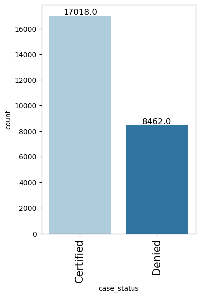

```python
labeled_barplot(data, "case_status")
```

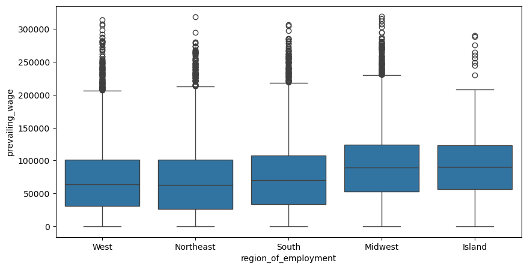

```python
plt.figure(figsize=(10, 5))
sns.boxplot(data=data, x="region_of_employment", y="prevailing_wage")
plt.show()
```

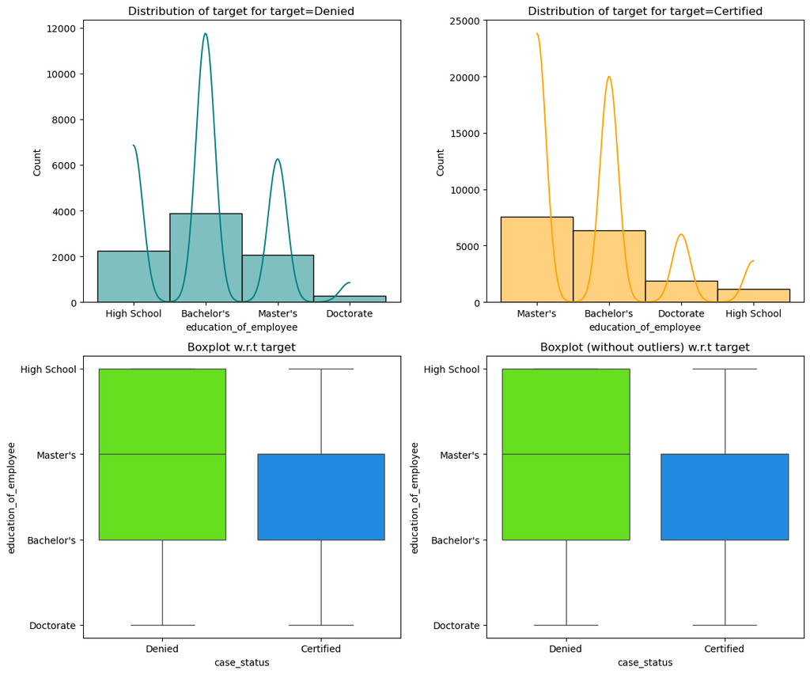

```python
distribution_plot_wrt_target(data, "education_of_employee", "case_status")
```

#### 1. What is the distribution of visa case statuses (certified vs. denied)?

1. What is the distribution of visa case statuses (certified vs. denied)?

66% (17018) of applicants get approved while 33% (8462) of the applicants get denied.

Return to Questions:

Return to Questions

Return to Questions:

Return to Questions

```
case_status            Certified  Denied    All
education_of_employee
All                        17018    8462  25480
Bachelor's                  6367    3867  10234
High School                 1164    2256   3420
Master's                    7575    2059   9634
Doctorate                   1912     280   2192
------------------------------------------------------------------------------------------------------------------------
```

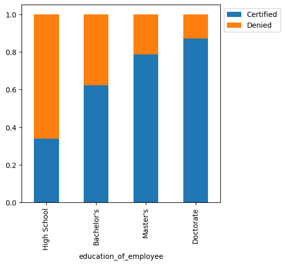

```python
stacked_barplot(data, "education_of_employee", "case_status")
```

#### 2. How does the education level of employees impact visa approval rates?

2. How does the education level of employees impact visa approval rates?

Return to Questions:

Return to Questions

```
case_status         Certified  Denied    All
has_job_experience
All                     17018    8462  25480
N                        5994    4684  10678
Y                       11024    3778  14802
------------------------------------------------------------------------------------------------------------------------
```

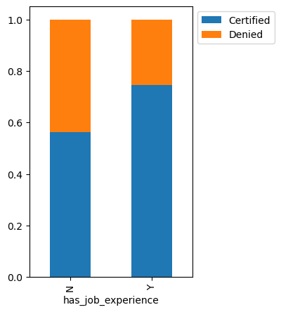

```python
stacked_barplot(data, "has_job_experience", "case_status")
```

#### 3. Is there a significant difference in visa approval rates between employees with and without prior job experience?

3. Is there a significant difference in visa approval rates between employees with and without prior job experience?

Return to Questions:

Return to Questions

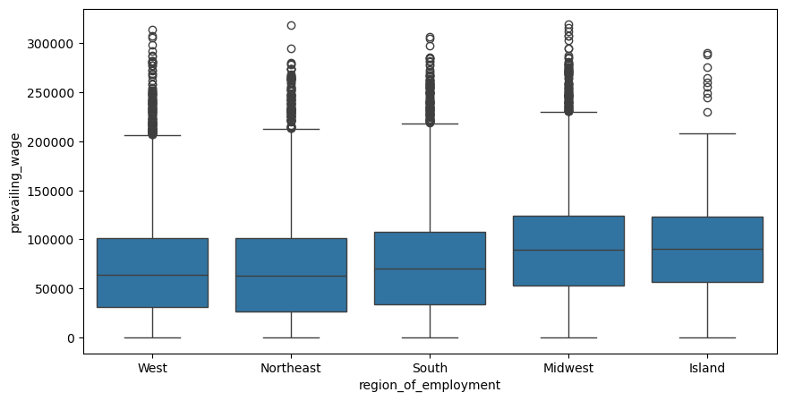

```python
plt.figure(figsize=(10, 5))
sns.boxplot(data=data, x="region_of_employment", y="prevailing_wage")
plt.show()
```

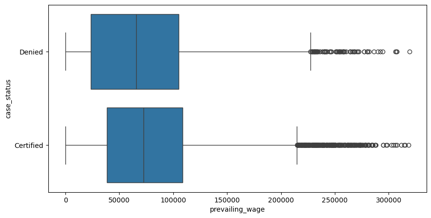

```python
plt.figure(figsize=(10, 5))
sns.boxplot(x="prevailing_wage", y="case_status", data=data)
plt.show()
```

#### 4. How does the `prevailing_wage` affect visa approval? Do higher wages lead to higher chances of approval?

4. How does the `prevailing_wage` affect visa approval? Do higher wages lead to higher chances of approval?

`prevailing_wage` does not seem to have a huge affect on visa approval.

Return to Questions:

Return to Questions

```
case_status           Certified  Denied    All
region_of_employment
All                       17018    8462  25480
Northeast                  4526    2669   7195
West                       4100    2486   6586
South                      4913    2104   7017
Midwest                    3253    1054   4307
Island                      226     149    375
------------------------------------------------------------------------------------------------------------------------
```

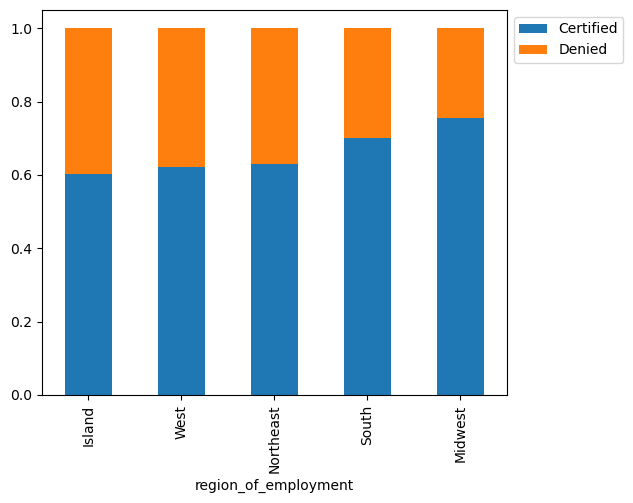

```python
stacked_barplot(data, "region_of_employment", "case_status")
```

#### 5. Do certain regions in the US have higher visa approval rates compared to others?

5. Do certain regions in the US have higher visa approval rates compared to others?

66.78% of applicants get approved while 33.21% of the applicants get denied. Here is the breakdown by region:

- 19.28% of South get approved while 8.25% of get denied
- 17.76% of Northeast get approved while 10.47% of get denied
- 16.09% of West get approved while 9.75% of get denied
- 12.76% of Midwest get approved while 4.13% of get denied
- 00.88% of Island get approved while 0.58% of get denied

Return to Questions:

Return to Questions

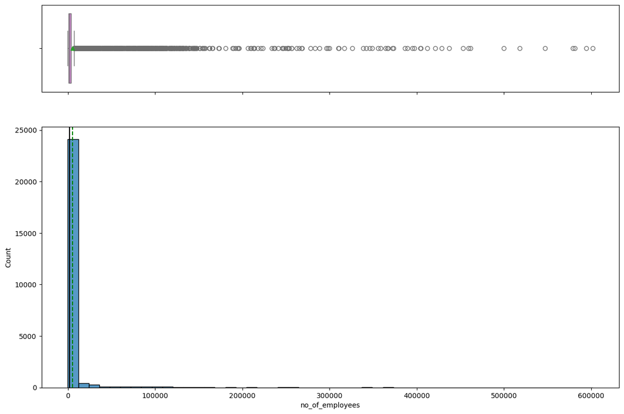

```python
histogram_boxplot(data, 'no_of_employees', bins = 50)
```

#### 6. How does the number of employees in a company influence visa approval? Do larger companies have a higher approval rate?

6. How does the number of employees in a company influence visa approval? Do larger companies have a higher approval rate?

It seems that larger companies do not have a higher approval rate. There does not seem to be a strong correlation of visa approvals.

Return to Questions:

Return to Questions

```
case_status    Certified  Denied    All
continent
All                17018    8462  25480
Asia               11012    5849  16861
North America       2037    1255   3292
Europe              2957     775   3732
South America        493     359    852
Africa               397     154    551
Oceania              122      70    192
------------------------------------------------------------------------------------------------------------------------
```

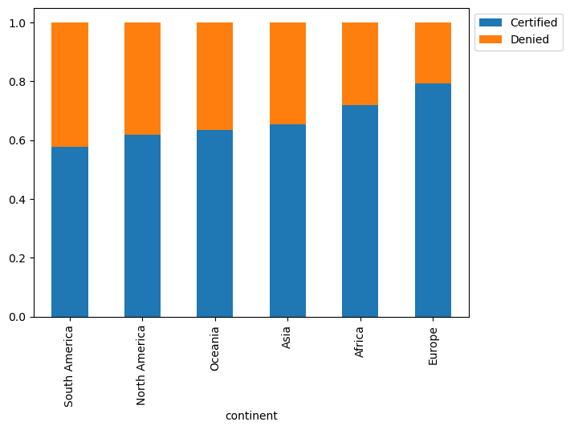

```python
stacked_barplot(data, "continent", "case_status")
```

#### 7. Are visa approval rates different across various continents of employees? Which continent has the highest and lowest approval rates?

7. Are visa approval rates different across various continents of employees? Which continent has the highest and lowest approval rates?

66% of applicants get approved while 33% of the applicants get denied. Here is the breakdown from highest to lowest by continent:

Return to Questions:

Return to Questions

#### Observation from the Boxplot graphs

Back to Table of Contents

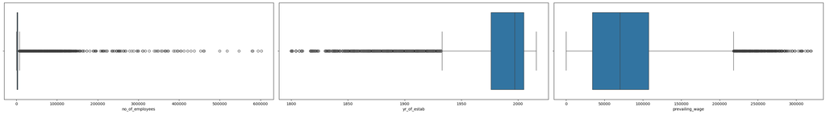

```python
plt.figure(figsize=(30, 12))

# defining the list of numerical features to plot
features = data.select_dtypes(include=['number']).columns.tolist()

# creating the histograms
for i, feature in enumerate(features):
    plt.subplot(3, 3, i+1)    # assign a subplot in the main plot
    sns.boxplot(data=data, x=feature)    # plot the histogram

plt.tight_layout()    # to add spacing between plots
plt.show()
```

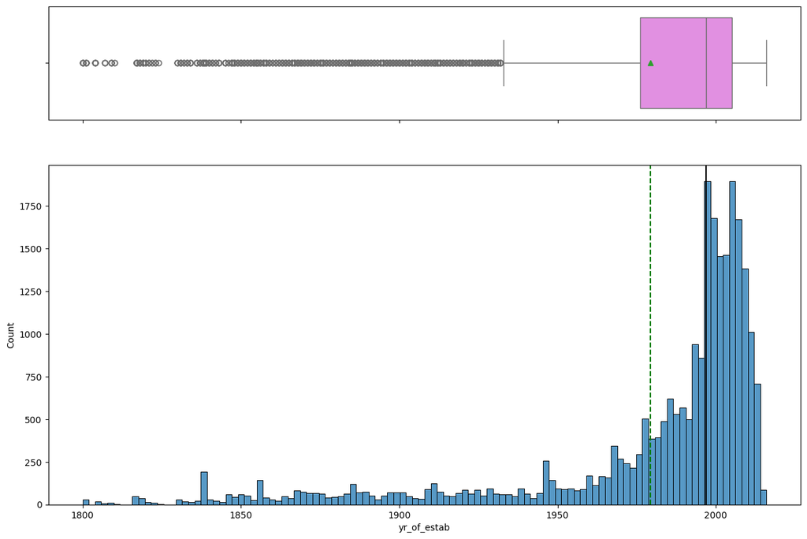

```python
histogram_boxplot(data, "yr_of_estab")
```

```python
labeled_barplot(data, "yr_of_estab")
```

[figure not shown]

Back to Table of Contents

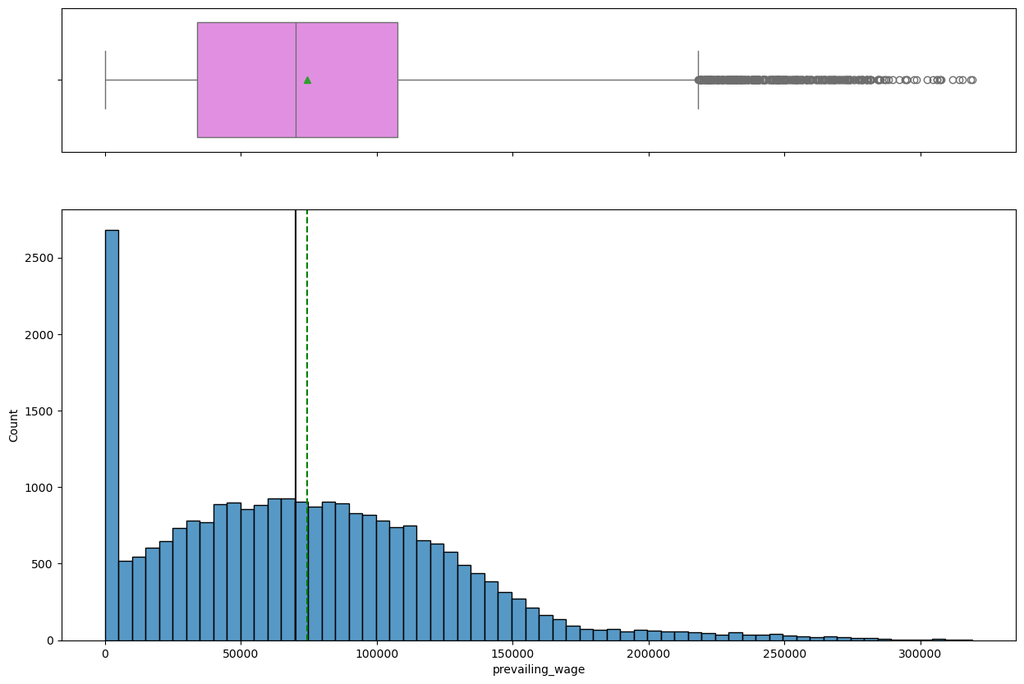

```python
histogram_boxplot(data, "prevailing_wage")
```

### Bivariate Analysis

Bivariate Analysis

Back to Table of Contents

#### Observations from the Heatmap

##### Negative Correlations

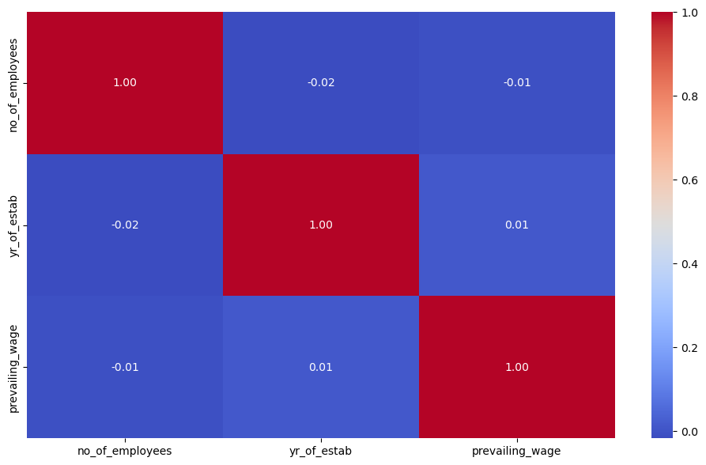

```python
cols_list = data.select_dtypes(include=np.number).columns.tolist()

plt.figure(figsize=(12, 7))
sns.heatmap(data[cols_list].corr(), annot=True, fmt="0.2f", cmap="coolwarm")
plt.show()
```

- This pairplot shows the quaulity of the features of the data.
- Looking diagonally at each of the graphs, it shows the skewing of the data.

Back to Table of Contents

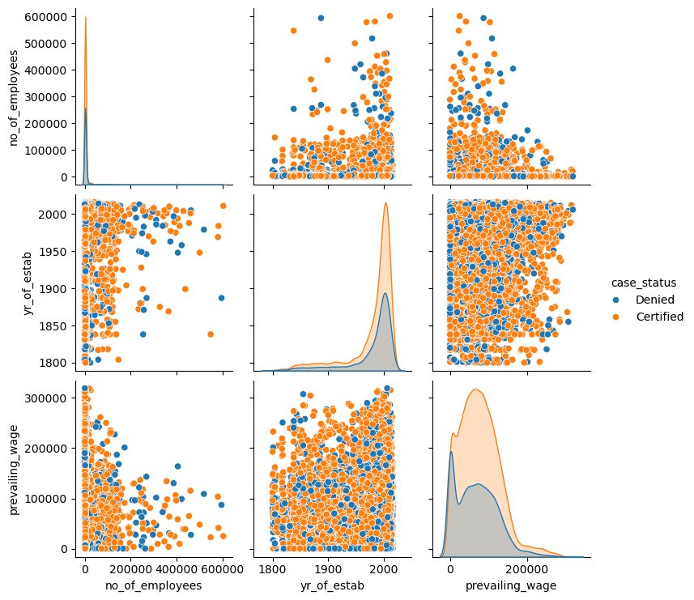

```python
#A pairplot of the data
sns.pairplot(data=data, hue='case_status', diag_kind="kde")
plt.show()
```

## Data Pre-Processing (Prepation for Modeling)

Data Pre-Processing (Prepation for Modeling)

Back to Table of Contents

```python
# Checks for duplicates in the data
data.duplicated().sum()
```

```
np.int64(0)
```

There are no duplicates.

```python
# Let's check for missing values in the data
round(data.isnull().sum() / data.isnull().count() * 100, 2)
```

```
continent               0.000
education_of_employee   0.000
has_job_experience      0.000
requires_job_training   0.000
no_of_employees         0.000
yr_of_estab             0.000
region_of_employment    0.000
prevailing_wage         0.000
unit_of_wage            0.000
full_time_position      0.000
case_status             0.000
dtype: float64
```

There are no missing values.

```python
# Confirmaing the distribution of the case_status variance
data["case_status"].value_counts(1)
```

```
case_status
Certified   0.668
Denied      0.332
Name: proportion, dtype: float64
```

```python
data["case_status"] = data["case_status"].apply(lambda x: 1 if x == "Certified" else 0)

# Separating the independent and dependent variables:
X = data.drop(["case_status"], axis=1)
y = data["case_status"]


X = pd.get_dummies(X, drop_first=True)
# X = X.astype(float)

# Splitting data into training, validation and test set:
# first we split data into 2 parts, say temporary and test

X_temp, X_test, y_temp, y_test = train_test_split(
    X, y, test_size=0.2, random_state=1, stratify=y
)

# then we split the temporary set into train and validation

X_train, X_val, y_train, y_val = train_test_split(
    X_temp, y_temp, test_size=0.25, random_state=1, stratify=y_temp
)
```

```python
print("Shape of Training set : ", X_train.shape)
print("Shape of the Validation set: ", X_val.shape)
print("Shape of test set : ", X_test.shape)
print("Percentage of classes in training set:")
print(y_train.value_counts(normalize=True))
print("Percentage of classes in validation set:")
print(y_val.value_counts(normalize=True))
print("Percentage of classes in test set:")
print(y_test.value_counts(normalize=True))
```

```
Shape of Training set :  (15288, 21)
Shape of the Validation set:  (5096, 21)
Shape of test set :  (5096, 21)
Percentage of classes in training set:
case_status
1   0.668
0   0.332
Name: proportion, dtype: float64
Percentage of classes in validation set:
case_status
1   0.668
0   0.332
Name: proportion, dtype: float64
Percentage of classes in test set:
case_status
1   0.668
0   0.332
Name: proportion, dtype: float64
```

## Model Building

Model Building

Back to Table of Contents

### Model evaluation criterion

**The Models below can wrongly:**

- FP - Predict that a visa applicant will get certified but in reality, the visa application gets denied.
- FN - Predict that a visa applicant will not get certified but in reality, the visa application gets certified.

**Which case is more important?**

- Both the cases are important as:
- If a visa is certified when it should be denied, the wrong employee will get the job position and a US citizen will not receive an opportunity for a position.
- If a visa is denied when it should be certified, the US job market loses a suitable employee that could have contributed to the economy.

**How to reduce the losses?**

- `F1 Score` can be used a the metric for evaluation of the model, greater the `F1 Score` higher are the chances of minimizing False Negatives and False Positives.
- We will use balanced class weights so that model focuses equally on both classes.
- `model_performance_classification_sklearn` function will be used to check the model performance of models.
- `confusion_matrix_sklearn` function will be used to plot the confusion matrix.

```python
# Defining a function to compute different metrics to check performance of a classification model built using sklearn

def model_performance_classification_sklearn(model, predictors, target):
    """
    Function to compute different metrics to check classification model performance

    model: classifier
    predictors: independent variables
    target: dependent variable
    """

    # predicting using the independent variables
    pred = model.predict(predictors)

    acc = accuracy_score(target, pred)  # to compute Accuracy
    recall = recall_score(target, pred)  # to compute Recall
    precision = precision_score(target, pred)  # to compute Precision
    f1 = f1_score(target, pred)  # to compute F1-score

    # creating a dataframe of metrics
    df_perf = pd.DataFrame(
        {"Accuracy": acc, "Recall": recall, "Precision": precision, "F1": f1,},
        index=[0],
    )

    return df_perf
```

```python
def confusion_matrix_sklearn(model, predictors, target):
    """
    To plot the confusion_matrix with percentages

    model: classifier
    predictors: independent variables
    target: dependent variable
    """
    y_pred = model.predict(predictors)
    cm = confusion_matrix(target, y_pred)
    labels = np.asarray(
        [
            ["{0:0.0f}".format(item) + "\n{0:.2%}".format(item / cm.flatten().sum())]
            for item in cm.flatten()
        ]
    ).reshape(2, 2)

    plt.figure(figsize=(6, 4))
    sns.heatmap(cm, annot=labels, fmt="")
    plt.ylabel("True label")
    plt.xlabel("Predicted label")
```

#### Model Building - Original Data

Model Building - Original Data

```python
models = []  # Empty list to store all the models

# Appending models into the list
models.append(("Bagging", BaggingClassifier(estimator=DecisionTreeClassifier(random_state=1, class_weight='balanced'), random_state=1)))
models.append(("Random forest", RandomForestClassifier(random_state=1, class_weight='balanced')))
models.append(("GBM", GradientBoostingClassifier(random_state=1)))
models.append(("Adaboost", AdaBoostClassifier(random_state=1)))
models.append(("dtree", DecisionTreeClassifier(random_state=1, class_weight='balanced')))

print("\nTraining Performance:\n")
for name, model in models:
    model.fit(X_train, y_train)
    scores = recall_score(y_train, model.predict(X_train))
    print("{}: {}".format(name, scores))

print("\nValidation Performance:\n")
for name, model in models:
    model.fit(X_train, y_train)
    scores_val = recall_score(y_val, model.predict(X_val))
    print("{}: {}".format(name, scores_val))
```

```
Training Performance:

Bagging: 0.9888344760039177
Random forest: 1.0
GBM: 0.8796278158667973
Adaboost: 0.8882468168462292
dtree: 1.0

Validation Performance:

Bagging: 0.7831962397179788
Random forest: 0.8407755581668626
GBM: 0.8742655699177438
Adaboost: 0.8807285546415982
dtree: 0.745005875440658
```

```python
print("\nOriginal Data - Training and Validation Performance Difference\n")

for name, model in models:
    model.fit(X_train, y_train)
    scores_train = recall_score(y_train, model.predict(X_train))
    scores_val = recall_score(y_val, model.predict(X_val))
    difference1 = scores_train - scores_val
    print("{}: Training Score: {:.4f}, Validation Score: {:.4f}, Difference: {:.4f}".format(name, scores_train, scores_val, difference1))
```

```
Original Data - Training and Validation Performance Difference

Bagging: Training Score: 0.9888, Validation Score: 0.7832, Difference: 0.2056
Random forest: Training Score: 1.0000, Validation Score: 0.8408, Difference: 0.1592
GBM: Training Score: 0.8796, Validation Score: 0.8743, Difference: 0.0054
Adaboost: Training Score: 0.8882, Validation Score: 0.8807, Difference: 0.0075
dtree: Training Score: 1.0000, Validation Score: 0.7450, Difference: 0.2550
```

#### Model Building - Oversampled Data

Model Building - Oversampled Data

Back to Table of Contents

```python
print("Before Oversampling, counts of label 'Certified': {}".format(sum(y_train == 1)))
print("Before Oversampling, counts of label 'Denied': {} \n".format(sum(y_train == 0)))

sm = SMOTE(
    sampling_strategy=1, k_neighbors=5, random_state=1
)  # Synthetic Minority Over Sampling Technique
X_train_over, y_train_over = sm.fit_resample(X_train, y_train)


print("After Oversampling, counts of label 'Certified': {}".format(sum(y_train_over == 1)))
print("After Oversampling, counts of label 'Denied': {} \n".format(sum(y_train_over == 0)))


print("After Oversampling, the shape of train_X: {}".format(X_train_over.shape))
print("After Oversampling, the shape of train_y: {} \n".format(y_train_over.shape))
```

```
Before Oversampling, counts of label 'Certified': 10210
Before Oversampling, counts of label 'Denied': 5078

After Oversampling, counts of label 'Certified': 10210
After Oversampling, counts of label 'Denied': 10210

After Oversampling, the shape of train_X: (20420, 21)
After Oversampling, the shape of train_y: (20420,)
```

```python
models = []  # Empty list to store all the models

# Appending models into the list
models.append(("Bagging", BaggingClassifier(estimator=DecisionTreeClassifier(random_state=1, class_weight='balanced'), random_state=1)))
models.append(("Random forest", RandomForestClassifier(random_state=1, class_weight='balanced')))
models.append(("GBM", GradientBoostingClassifier(random_state=1)))
models.append(("Adaboost", AdaBoostClassifier(random_state=1)))
models.append(("dtree", DecisionTreeClassifier(random_state=1, class_weight='balanced')))

print("\n" "Training Performance:" "\n")
for name, model in models:
    model.fit(X_train_over, y_train_over)
    scores = recall_score(y_train_over, model.predict(X_train_over))
    print("{}: {}".format(name, scores))

print("\n" "Validation Performance:" "\n")

for name, model in models:
    model.fit(X_train_over, y_train_over)
    scores = recall_score(y_val, model.predict(X_val))
    print("{}: {}".format(name, scores))
```

```
Training Performance:

Bagging: 0.9827619980411362
Random forest: 1.0
GBM: 0.8514201762977474
Adaboost: 0.8841332027424094
dtree: 1.0

Validation Performance:

Bagging: 0.7511750881316098
Random forest: 0.8131609870740305
GBM: 0.8448883666274971
Adaboost: 0.882491186839013
dtree: 0.717978848413631
```

```python
print("\nOversampling - Training and Validation Performance Difference:\n")

for name, model in models:
    model.fit(X_train_over, y_train_over)
    scores_train = recall_score(y_train_over, model.predict(X_train_over))
    scores_val = recall_score(y_val, model.predict(X_val))
    difference2 = scores_train - scores_val
    print("{}: Training Score: {:.4f}, Validation Score: {:.4f}, Difference: {:.4f}".format(name, scores_train, scores_val, difference2))
```

```
Oversampling - Training and Validation Performance Difference:

Bagging: Training Score: 0.9828, Validation Score: 0.7512, Difference: 0.2316
Random forest: Training Score: 1.0000, Validation Score: 0.8132, Difference: 0.1868
GBM: Training Score: 0.8514, Validation Score: 0.8449, Difference: 0.0065
Adaboost: Training Score: 0.8841, Validation Score: 0.8825, Difference: 0.0016
dtree: Training Score: 1.0000, Validation Score: 0.7180, Difference: 0.2820
```